# ML Term 3 Project - Store Item Sales Demand Forecast

1. Objective
2. Data Loading and Visualization  
   2(a).Import the dataset  
   2(b).Load Dataset  
   2(c).Overview of data  
   2(d).Distribution of Sales  
   2(e).Comparing sales prices by date  
   2(f).Comparing Annual sales between stores  
   2(g).Comparing Monthly sales between stores  
   2(h).Comparing 3 months sales between stores  
   2(i).Comparing Weekly sales between stores  
   2(j).Boxplot
3. Analysis for store 1 and Item 1
4. Decomposition
5. Stationarity Check  
   5(a).using rolling statistics plot (Visual_Method)  
   5(b).using Augumented Dickey Fuller Test
6. Data Transformation to achieve Stationarity  
   6.1. log scale transform  
   6.2. log scale Minus Moving Average  
   6.3. Exponential Decay Transformation  
   6.4. Log Scale Shifting
7. Plotting*ACF*&_PACF
8. Building Models  
   8.1. AR Model  
   8.2. ARMA Model  
   8.3. ARIMA Model

### 1. Objective

- Build a model to forecast 3 months of item-level sales data at a store location.
- The data is classified in date/time ,storeID ,itemID and sales

### 2. Data Loading and Visualization

#### **2(a).Import the dataset**

```python
import sys
!{sys.executable} -m pip install pandas_profiling
```

```python
import numpy as np
import pandas as pd
import pandas_profiling
import matplotlib.pylab as plt
%matplotlib inline
import seaborn as sns
import warnings
warnings.filterwarnings("ignore")

import statsmodels.api as sm

color = sns.color_palette()
sns.set_style('darkgrid')
```

#### **2(b).Load Dataset**

```python
dataset  =  pd.read_csv('https://raw.githubusercontent.com/insaid2018/Term-3/master/Projects/Store_Item_demand_forecast.csv')
dataset.head()
```

|  | date | store | item | sales |
| --- | --- | --- | --- | --- |
| 0 | 2013-01-01 | 1 | 1 | 13 |
| 1 | 2013-01-02 | 1 | 1 | 11 |
| 2 | 2013-01-03 | 1 | 1 | 14 |
| 3 | 2013-01-04 | 1 | 1 | 13 |
| 4 | 2013-01-05 | 1 | 1 | 10 |

```python
dataset.shape
```

```
(913000, 4)
```

```python
dataset.isnull().sum()
```

```
date     0
store    0
item     0
sales    0
dtype: int64
```

```
There is no nullvalues in the dataset.
```

```python
dataset.describe()
```

|  | store | item | sales |
| --- | --- | --- | --- |
| count | 913000.000000 | 913000.000000 | 913000.000000 |
| mean | 5.500000 | 25.500000 | 52.250287 |
| std | 2.872283 | 14.430878 | 28.801144 |
| min | 1.000000 | 1.000000 | 0.000000 |
| 25% | 3.000000 | 13.000000 | 30.000000 |
| 50% | 5.500000 | 25.500000 | 47.000000 |
| 75% | 8.000000 | 38.000000 | 70.000000 |
| max | 10.000000 | 50.000000 | 231.000000 |

```python
profile = pandas_profiling.ProfileReport(dataset)
profile.to_file(outputfile="C:/project/dataset_preprocessing.html")
```

#### **2(c).Overview of data**

```python
print("number of different items: %i" %(len(np.unique(dataset.item))))
print("number of different stores: %i" %(len(np.unique(dataset.store))))
print("number of different dates: %i" %(len(np.unique(dataset.date))))
print("maximun date in data: %s" %(max(dataset.date)))

print("minimum date in data: %s" %(min(dataset.date)))
```

```
number of different items: 50
number of different stores: 10
number of different dates: 1826
maximun date in data: 2017-12-31
minimum date in data: 2013-01-01
```

**Data Visualizing**

#### **2(d). Distribution of Sales**

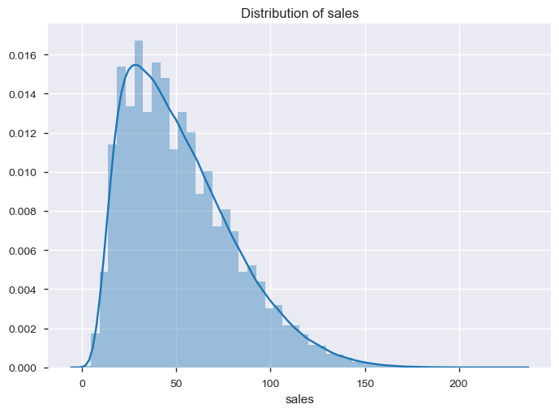

```python
sns.distplot(dataset["sales"])
plt.title('Distribution of sales')
plt.savefig('C:/project/Distribution of sales.png',bbox_inches='tight')
```

**Observation**

```python
dataset['weekday']=pd.DatetimeIndex(dataset['date']).weekday
dataset['day']=pd.DatetimeIndex(dataset['date']).day
dataset['month']=pd.DatetimeIndex(dataset['date']).month
dataset['year']=pd.DatetimeIndex(dataset['date']).year
dataset.head()
```

|  | date | store | item | sales | weekday | day | month | year |
| --- | --- | --- | --- | --- | --- | --- | --- | --- |
| 0 | 2013-01-01 | 1 | 1 | 13 | 1 | 1 | 1 | 2013 |
| 1 | 2013-01-02 | 1 | 1 | 11 | 2 | 2 | 1 | 2013 |
| 2 | 2013-01-03 | 1 | 1 | 14 | 3 | 3 | 1 | 2013 |
| 3 | 2013-01-04 | 1 | 1 | 13 | 4 | 4 | 1 | 2013 |
| 4 | 2013-01-05 | 1 | 1 | 10 | 5 | 5 | 1 | 2013 |

```python
dataset1 = dataset[dataset['date']<'2017-10-01']
dataset1.tail()
```

|  | date | store | item | sales | weekday | day | month | year |
| --- | --- | --- | --- | --- | --- | --- | --- | --- |
| 912903 | 2017-09-26 | 10 | 50 | 79 | 1 | 26 | 9 | 2017 |
| 912904 | 2017-09-27 | 10 | 50 | 80 | 2 | 27 | 9 | 2017 |
| 912905 | 2017-09-28 | 10 | 50 | 82 | 3 | 28 | 9 | 2017 |
| 912906 | 2017-09-29 | 10 | 50 | 90 | 4 | 29 | 9 | 2017 |
| 912907 | 2017-09-30 | 10 | 50 | 103 | 5 | 30 | 9 | 2017 |

```python
dataset2 =dataset[dataset['date']>='2017-10-01']
dataset2.head()
```

|  | date | store | item | sales | weekday | day | month | year |
| --- | --- | --- | --- | --- | --- | --- | --- | --- |
| 1734 | 2017-10-01 | 1 | 1 | 21 | 6 | 1 | 10 | 2017 |
| 1735 | 2017-10-02 | 1 | 1 | 12 | 0 | 2 | 10 | 2017 |
| 1736 | 2017-10-03 | 1 | 1 | 18 | 1 | 3 | 10 | 2017 |
| 1737 | 2017-10-04 | 1 | 1 | 15 | 2 | 4 | 10 | 2017 |
| 1738 | 2017-10-05 | 1 | 1 | 20 | 3 | 5 | 10 | 2017 |

```python
dataset2.shape
```

```
(46000, 8)
```

#### **2(e). Comparing sales prices by date**

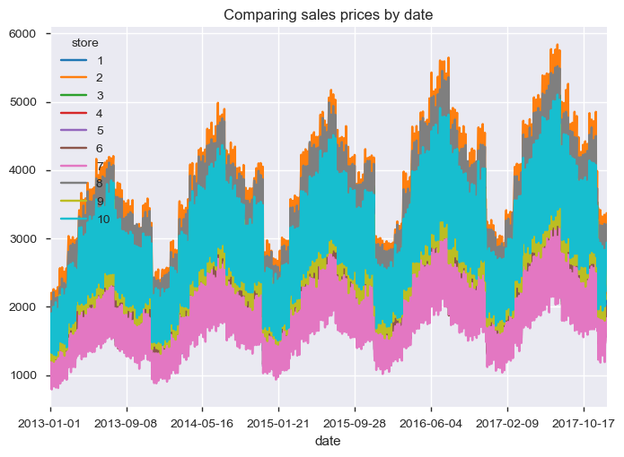

```python
a=dataset.groupby(['date','store']).sum()
d=a.unstack()
d.plot(y='sales')
plt.title('Comparing sales prices by date')
plt.savefig('C:/project/Comparing sales prices by date.png',bbox_inches='tight')
```

**Observation**

The Growth of the Sales Price are Multiplicative with increasing TREND and SEASONALITY.

#### **2(f). Comparing Annual sales between stores**

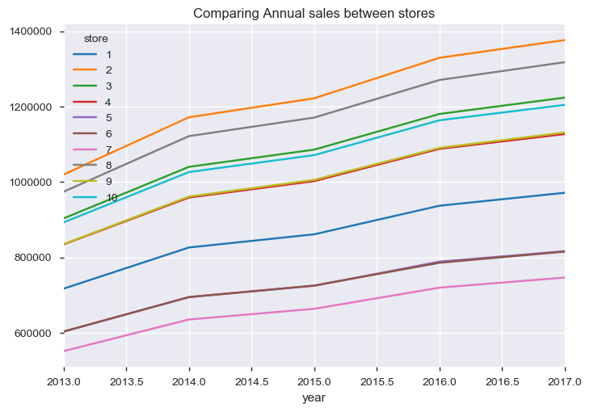

```python
b=dataset.groupby(['year','store']).sum()
plt.figure(figsize=(15,10))
d=b.unstack()
d.plot(y='sales')
plt.title('Comparing Annual sales between stores')
plt.savefig('C:/project/Comparing Annual sales between stores.png',bbox_inches='tight')
```

**Observation**

Here we can see there is upward Trend in the data from the year 2013 to 2017

#### **2(g). Comparing Monthly sales between stores**

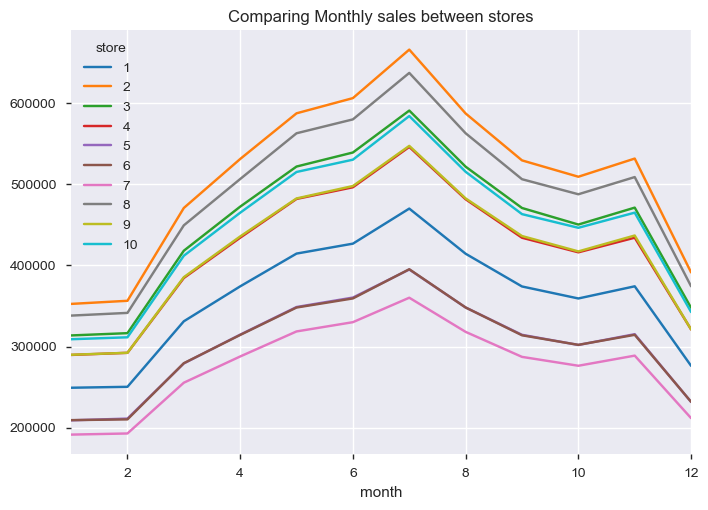

```python
c=dataset.groupby(['month', 'store']).sum()
plt.figure(figsize=(15,10))
d=c.unstack()
d.plot(y='sales')
plt.title('Comparing Monthly sales between stores')
plt.savefig('C:/project/Comparing Monthly sales between stores.png',bbox_inches='tight')
```

**Observation**

We can observe that there is more sales in the month of July

#### **2(h). Comparing 3 months sales between stores**

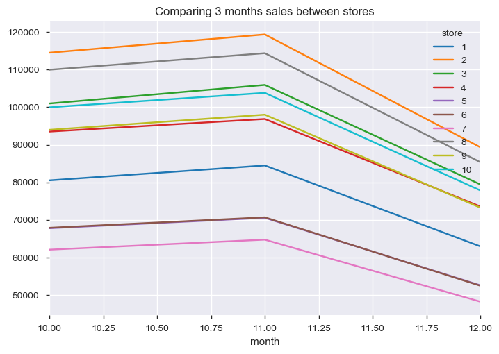

```python
f=dataset2.groupby(['month', 'store']).sum()
plt.figure(figsize=(15,10))
d=f.unstack()
d.plot(y='sales')
plt.title('Comparing 3 months sales between stores')
plt.savefig('C:/project/Comparing 3 months sales between stores.png',bbox_inches='tight')
```

**Observation**

We can see there is a slight increase in sales from october to november which ends up decreasing in the third month.

#### **2(i). Comparing Weekly sales between stores**

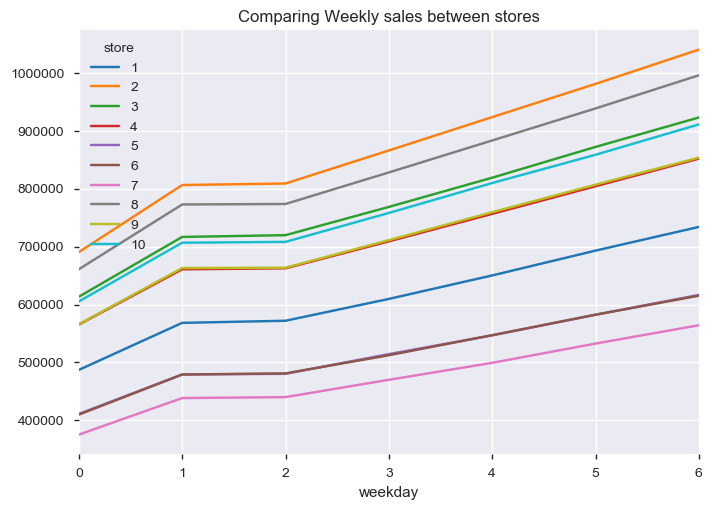

```python
e=dataset.groupby(['weekday','store']).sum()
plt.figure(figsize=(15,10))
d=e.unstack()
d.plot(y='sales')
plt.title('Comparing Weekly sales between stores')
plt.savefig('C:/project/Comparing Weekly sales between stores.png',bbox_inches='tight')
```

**Observation**

#### **2(j). Boxplot**

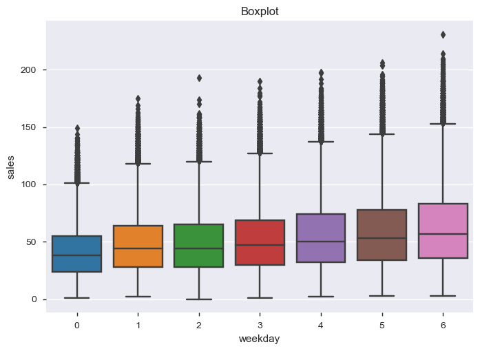

```python
sns.boxplot(x="weekday", y="sales", data=dataset)
plt.title('Boxplot')
plt.savefig('C:/project/Boxplot.png',bbox_inches='tight')
```

**Observation**

Monday=0, Sunday=6.

### 3. Analysis for store 1 and Item 1

```python
store1item1= dataset[dataset['store']==1]
store1item1= store1item1[dataset['item']==1]
```

```python
#store1item1 = store1item1.set_index('date')
store1item1['sales'] =store1item1['sales'].astype(float)

store1item1.head()
```

|  | date | store | item | sales | weekday | day | month | year |
| --- | --- | --- | --- | --- | --- | --- | --- | --- |
| 0 | 2013-01-01 | 1 | 1 | 13.0 | 1 | 1 | 1 | 2013 |
| 1 | 2013-01-02 | 1 | 1 | 11.0 | 2 | 2 | 1 | 2013 |
| 2 | 2013-01-03 | 1 | 1 | 14.0 | 3 | 3 | 1 | 2013 |
| 3 | 2013-01-04 | 1 | 1 | 13.0 | 4 | 4 | 1 | 2013 |
| 4 | 2013-01-05 | 1 | 1 | 10.0 | 5 | 5 | 1 | 2013 |

```python
##### store1item1['date']  =  pd.to_datetime(store1item1['date'],infer_datetime_format = True)             #convert from string to datetime

indexedDataset  =  store1item1.set_index(['date'])
indexedDataset= indexedDataset.drop(columns=["store","item","weekday","day","month","year"])
indexedDataset.head()
```

| date | sales |
| --- | --- |
| 2013-01-01 | 13.0 |
| 2013-01-02 | 11.0 |
| 2013-01-03 | 14.0 |
| 2013-01-04 | 13.0 |
| 2013-01-05 | 10.0 |

```python
indexedDataset.shape
```

```
(1826, 1)
```

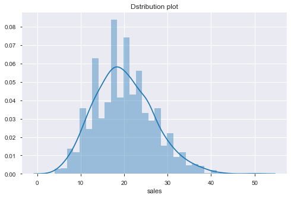

```python
sns.distplot(store1item1["sales"])
plt.title('Dstribution plot')
plt.savefig('C:/project/Dstribution plot.png',bbox_inches='tight')
```

**Observation**

From this graph we can see the sales is normally distributed for item 1 in store1.

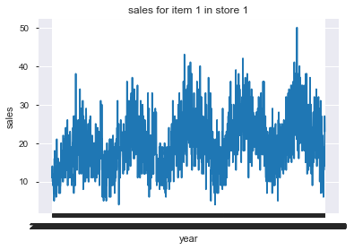

```python
import matplotlib.pylab as plt
%matplotlib inline

plt.xlabel('year')
plt.ylabel('sales')
plt.plot(indexedDataset['sales'])
plt.title('sales for item 1 in store 1')
plt.savefig('C:/project/sales for item 1 in store 1.png',bbox_inches='tight')
```

### 4. Decomposition

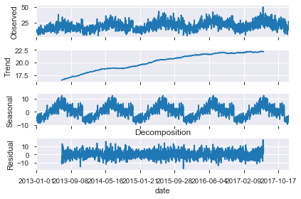

```python
from statsmodels.tsa.seasonal import seasonal_decompose
fig = seasonal_decompose(indexedDataset['sales'], model='additive', freq=365).plot()
plt.title('Decomposition')
plt.savefig('C:/project/Decomposition.png',bbox_inches='tight')
```

**Observation**

From the plot above, we can see that there is a Trend compoenent and seasonal component in the series.

### 5. Stationarity Check

#### 5(a). Checking stationarity using rolling statistics plot (Visual Method)

```python
# Determine rolling statistics
def rolling_means(time_series):
    rolmean  =  time_series.rolling(window = 12).mean()    #window size 12 denotes 12 months, giving rolling mean at yearly level
    rolstd  =  time_series.rolling(window = 12).std()

    from matplotlib.pylab import rcParams
    rcParams['figure.figsize']  =  8, 5

    orig  =  plt.plot(time_series, color = 'blue', label = 'Original')
    mean  =  plt.plot(rolmean, color = 'red', label = 'Rolling Mean')
    std  =  plt.plot(rolstd, color = 'black', label = 'Rolling Std')

    plt.legend(loc = 'best')
    plt.title('Rolling Mean & Standard Deviation')
    plt.show(block = False)
```

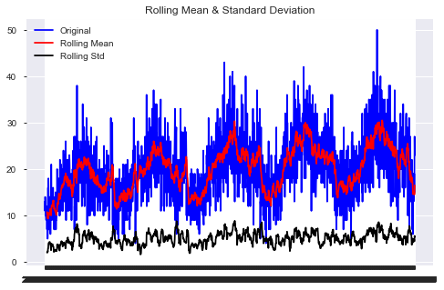

```python
rolling_means(indexedDataset['sales'])
```

#### 5(b). Checking stationarity using Augumented Dickey Fuller Test (Statistical Method)

```python
#Perform Augmented Dickey–Fuller test:
def adf_test(time_series):

    from statsmodels.tsa.stattools import adfuller
    dftest  =  adfuller(time_series, autolag = 'AIC')

    dfoutput  =  pd.Series(dftest[0:4], index = ['Test Statistic','p-value','#Lags Used','Number of Observations Used'])
    for key,value in dftest[4].items():

        dfoutput['Critical Value (%s)'%key]  =  value

    print('Results of Dickey Fuller Test:')
    print(dfoutput)
```

```python
adf_test(indexedDataset['sales'])
```

```
Results of Dickey Fuller Test:
Test Statistic                   -3.157671
p-value                           0.022569
#Lags Used                       23.000000
Number of Observations Used    1802.000000
Critical Value (1%)              -3.433984
Critical Value (5%)              -2.863145
Critical Value (10%)             -2.567625
dtype: float64
```

**Observation**

The Dickey-Fuller test the time series is not considered stationary as Test Statistic greater than 1% Critical Value and we can see visually that there is an upwards trend.

### 6. Data Transformation to achieve Stationarity ¶

**Try to make the data Stationary we will try**

1. Log scale transform
2. Log Scale Minus Moving Average
3. Exponential Decay
4. Shift Difference

#### **6.1. log scale transform** ¶

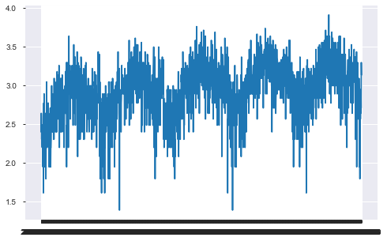

```python
#log scale transform
import numpy as np
from matplotlib.pylab import rcParams
rcParams['figure.figsize']  =  8, 5
indexedDataset_logScale  =  np.log(indexedDataset)
plt.plot(indexedDataset_logScale)
```

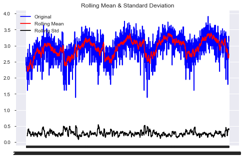

```python
rolling_means(indexedDataset_logScale.sales)
```

```python
adf_test(indexedDataset_logScale.sales)
```

```
Results of Dickey Fuller Test:
Test Statistic                   -3.594424
p-value                           0.005869
#Lags Used                       23.000000
Number of Observations Used    1802.000000
Critical Value (1%)              -3.433984
Critical Value (5%)              -2.863145
Critical Value (10%)             -2.567625
dtype: float64
```

**Observation**

#### **6.2. Log Scale Minus Moving Average**¶

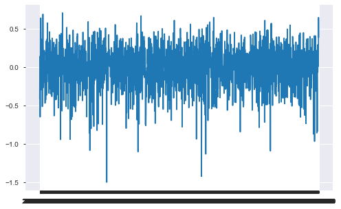

```python
movingAverage  =  indexedDataset_logScale.rolling(window = 12).mean()
datasetLogScaleMinusMovingAverage  =  indexedDataset_logScale - movingAverage

#Remove NAN values
datasetLogScaleMinusMovingAverage.dropna(inplace = True)
plt.plot(datasetLogScaleMinusMovingAverage)
```

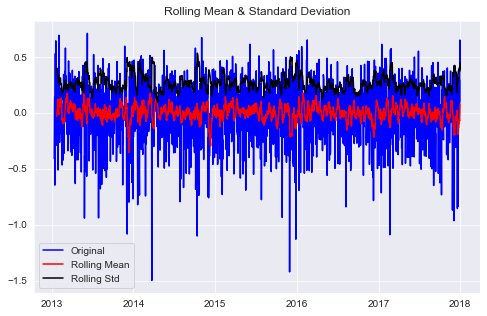

```python
rolling_means(datasetLogScaleMinusMovingAverage)
```

```python
adf_test(datasetLogScaleMinusMovingAverage.sales)
```

```
Results of Dickey Fuller Test:
Test Statistic                -1.031707e+01
p-value                        3.077488e-18
#Lags Used                     2.000000e+01
Number of Observations Used    1.794000e+03
Critical Value (1%)           -3.434000e+00
Critical Value (5%)           -2.863152e+00
Critical Value (10%)          -2.567628e+00
dtype: float64
```

**Observation**

Data is somewhat stationary

#### **6.3.Exponential Decay Transformation**¶

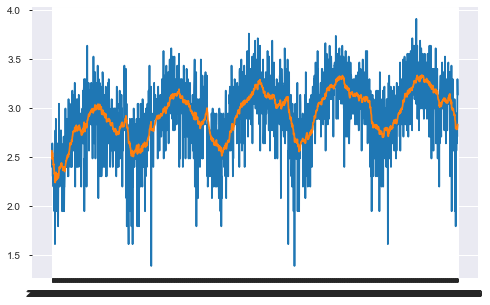

```python
exponentialDecayWeightedAverage  =  indexedDataset_logScale.ewm(halflife = 12, min_periods = 0, adjust = True).mean()
plt.plot(indexedDataset_logScale)
plt.plot(exponentialDecayWeightedAverage)

#tsa - transformations available
```

```python
def test_stationarity(time_series):
    rolling_stat(time_series)
```

[figure not shown]

```python
test_stationarity(exponentialDecayWeightedAverage)
```

```python
adf_test(exponentialDecayWeightedAverage.sales)
```

```
Results of Dickey Fuller Test:
Test Statistic                   -3.666915
p-value                           0.004603
#Lags Used                       24.000000
Number of Observations Used    1801.000000
Critical Value (1%)              -3.433986
Critical Value (5%)              -2.863146
Critical Value (10%)             -2.567625
dtype: float64
```

#### **6.4. Log Scale Shifting**

```python
datasetLogDiffShifting  =  indexedDataset_logScale - indexedDataset_logScale.shift()
```

```python
datasetLogDiffShifting.dropna(inplace = True)
```

```python
len(datasetLogDiffShifting)
```

```
1825
```

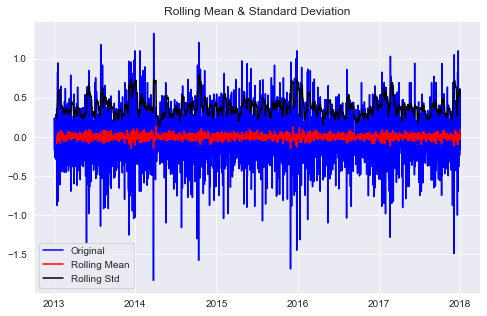

```python
rolling_means(datasetLogDiffShifting)
```

```python
adf_test(datasetLogDiffShifting.sales)
```

```
Results of Dickey Fuller Test:
Test Statistic                -1.259629e+01
p-value                        1.775858e-23
#Lags Used                     2.200000e+01
Number of Observations Used    1.802000e+03
Critical Value (1%)           -3.433984e+00
Critical Value (5%)           -2.863145e+00
Critical Value (10%)          -2.567625e+00
dtype: float64
```

**Observation**

The p-value is extremely small. Thus this series is very likely to be stationary.

So here we can see the much higher accuracy rate than Log scale transform, Log Scale Minus Moving Average and Exponential Decay. And so,we wll go ahead with the **Log Scale Shifting** i.e the Time Shifted dataset

**Data is now Stationary**

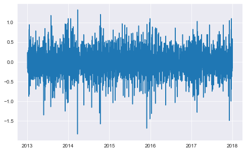

```python
plt.plot(datasetLogDiffShifting)
```

### 7. Plotting ACF & PACF

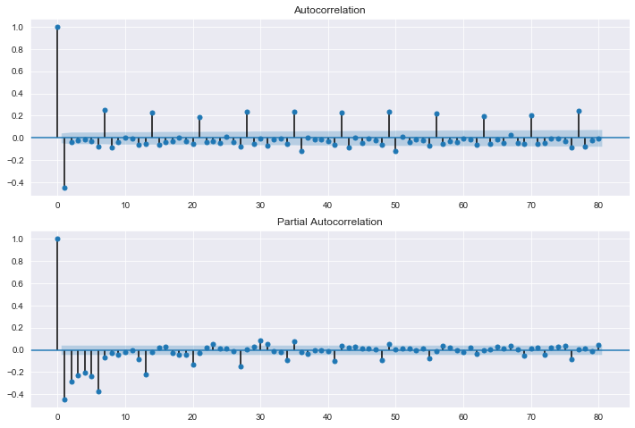

```python
from statsmodels.graphics.tsaplots import plot_acf, plot_pacf

fig = plt.figure(figsize=(12,8))
ax1 = fig.add_subplot(211)
fig = plot_acf(datasetLogDiffShifting.sales, lags=80, ax=ax1)
ax2 = fig.add_subplot(212)
fig = plot_pacf(datasetLogDiffShifting.sales, lags=80, ax=ax2)
```

**Obseration**

P, Q value - 7

Here we can see the acf and pacf both has a recurring pattern every 7 periods. Indicating a weekly pattern exists.

### 8. Building Models

**Let us forecaste deploying AR, ARMA and ARIMA model.**

#### 8.1. AR Model

*Using AR model to forecast the number of sales for 3 months.*

*Dividing the dataset into train and test. Keeping last 3 months data for testing the performance of our time series model.*

```python
datasetLogDiffShifting.head()
```

[output not shown]

```python
# Data Preparation
train, test = datasetLogDiffShifting[:len(datasetLogDiffShifting)-92], datasetLogDiffShifting[len(datasetLogDiffShifting)-92:]
train.head()
```

[output not shown]

```python
test.head()
```

| date | sales |
| --- | --- |
| 2017-10-01 | -0.356675 |
| 2017-10-02 | -0.559616 |
| 2017-10-03 | 0.405465 |
| 2017-10-04 | -0.182322 |
| 2017-10-05 | 0.287682 |

```python
test.tail()
```

| date | sales |
| --- | --- |
| 2017-12-27 | -0.133531 |
| 2017-12-28 | 0.305382 |
| 2017-12-29 | -0.236389 |
| 2017-12-30 | 0.587787 |
| 2017-12-31 | -0.160343 |

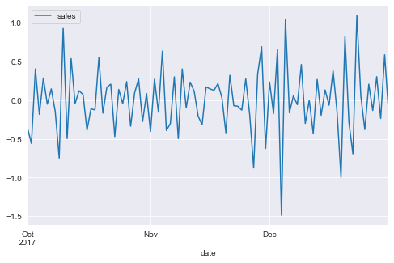

```python
test.plot()
```

```python
print(train.shape)
print(test.shape)
```

```
(1733, 1)
(92, 1)
```

```python
from statsmodels.tsa.ar_model import AR
model = AR(train)
model_fit = model.fit()
print('Lag: %s' % model_fit.k_ar)
print('Coefficients: %s' % model_fit.params)
```

```
Lag: 24
Coefficients: const        0.004402
L1.sales    -0.887081
L2.sales    -0.826873
L3.sales    -0.793328
L4.sales    -0.749942
L5.sales    -0.698274
L6.sales    -0.649725
L7.sales    -0.415803
L8.sales    -0.396870
L9.sales    -0.372371
L10.sales   -0.325342
L11.sales   -0.312817
L12.sales   -0.344624
L13.sales   -0.296448
L14.sales   -0.114079
L15.sales   -0.103083
L16.sales   -0.126063
L17.sales   -0.144913
L18.sales   -0.134916
L19.sales   -0.111339
L20.sales   -0.075815
L21.sales    0.058731
L22.sales    0.084017
L23.sales    0.068698
L24.sales    0.017769
dtype: float64
```

**Observation**

A 24 lag model was chosen and trained.

- Forecasting using the developed model and printing out the **3 month forecast of sales**

```python
# make predictions
predictions = model_fit.predict(start=len(train), end=len(train)+len(test)-1)
predictions.head()

for i in range(len(predictions)):
    print('predicted=%f, expected=%f' % (predictions[i], test.iloc[i]))
```

```
predicted=-0.186415, expected=-0.356675
predicted=-0.232092, expected=-0.559616
predicted=0.039613, expected=0.405465
predicted=0.023987, expected=-0.182322
predicted=0.074181, expected=0.287682
predicted=0.175328, expected=-0.051293
predicted=0.095938, expected=0.146603
predicted=-0.169944, expected=-0.146603
predicted=-0.224034, expected=-0.747214
predicted=0.041989, expected=0.938270
predicted=0.081429, expected=-0.496437
predicted=0.030314, expected=0.538997
predicted=0.115367, expected=-0.042560
predicted=0.061718, expected=0.122602
predicted=-0.131920, expected=0.074108
predicted=-0.180360, expected=-0.387766
predicted=0.018094, expected=-0.111226
predicted=0.101978, expected=-0.125163
predicted=0.055992, expected=0.550046
predicted=0.080383, expected=-0.167054
predicted=0.018755, expected=0.167054
predicted=-0.098933, expected=0.207639
predicted=-0.126395, expected=-0.470004
predicted=0.003576, expected=0.139762
predicted=0.056743, expected=-0.044452
predicted=0.053481, expected=0.241162
predicted=0.071090, expected=-0.336472
predicted=0.027330, expected=0.095310
predicted=-0.080588, expected=0.276253
predicted=-0.108893, expected=-0.276253
predicted=-0.004057, expected=0.087011
predicted=0.055947, expected=-0.405465
predicted=0.052028, expected=0.271934
predicted=0.049967, expected=-0.154151
predicted=0.010154, expected=0.635989
predicted=-0.063385, expected=-0.390866
predicted=-0.081307, expected=-0.302281
predicted=-0.005231, expected=0.302281
predicted=0.046938, expected=-0.496437
predicted=0.048364, expected=0.405465
```

[output cut: 37 more lines]

```
predicted=-0.019851, expected=0.382992
predicted=-0.020774, expected=-0.146603
predicted=-0.002944, expected=-0.998529
predicted=0.015348, expected=0.826679
predicted=0.019865, expected=-0.287682
predicted=0.011404, expected=-0.693147
predicted=-0.003524, expected=1.098612
predicted=-0.016465, expected=0.054067
predicted=-0.016682, expected=-0.379490
predicted=-0.002217, expected=0.207639
predicted=0.012882, expected=-0.133531
predicted=0.016762, expected=0.305382
predicted=0.009368, expected=-0.236389
predicted=-0.003324, expected=0.587787
predicted=-0.013658, expected=-0.160343
```

- **Model evaluation using Mean_squared_error**

```
Test MSE: 0.171
```

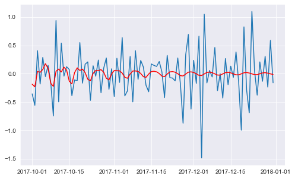

```python
from sklearn.metrics import mean_squared_error
from matplotlib import pyplot
error = mean_squared_error(test, predictions)
print('Test MSE: %.3f' % error)
# plot results

pyplot.plot(test)
pyplot.plot(predictions, color='red')
pyplot.show()
```

- Observing the plot of **__expected__** vs the **__predicted__** .

#### 8.2. ARMA Model

```python
from statsmodels.tsa.arima_model import ARMA
model = ARMA(train, order  = (7,7))
model_fit = model.fit()
print('Lag: %s' % model_fit.k_ar)
print('Coefficients: %s' % model_fit.params)
```

```
Lag: 7
Coefficients: const          0.000449
ar.L1.sales   -0.980352
ar.L2.sales   -0.979860
ar.L3.sales   -0.979721
ar.L4.sales   -0.979874
ar.L5.sales   -0.980331
ar.L6.sales   -0.979101
ar.L7.sales    0.020862
ma.L1.sales    0.107285
ma.L2.sales    0.080399
ma.L3.sales    0.099381
ma.L4.sales    0.104940
ma.L5.sales    0.088644
ma.L6.sales    0.102245
ma.L7.sales   -0.870005
dtype: float64
```

**Observation**

A 7 lag model was chosen and trained.

- Forecasting using the developed model and printing out the **3 month forecast of sales**

```python
# make predictions
predictions2 = model_fit.predict(start=len(train), end=len(train)+len(test)-1)
predictions2.head()

for i in range(len(predictions2)):
    print('predicted=%f, expected=%f' % (predictions2[i], test.iloc[i]))
```

```
predicted=-0.077149, expected=-0.356675
predicted=-0.440768, expected=-0.559616
predicted=0.202448, expected=0.405465
predicted=0.039366, expected=-0.182322
predicted=0.047784, expected=0.287682
predicted=0.078547, expected=-0.051293
predicted=0.088151, expected=0.146603
predicted=-0.014212, expected=-0.146603
predicted=-0.439143, expected=-0.747214
predicted=0.203027, expected=0.938270
predicted=0.038922, expected=-0.496437
predicted=0.047822, expected=0.538997
predicted=0.078717, expected=-0.042560
predicted=0.088237, expected=0.122602
predicted=-0.014911, expected=0.074108
predicted=-0.438844, expected=-0.387766
predicted=0.203578, expected=-0.111226
predicted=0.038476, expected=-0.125163
predicted=0.047862, expected=0.550046
predicted=0.078887, expected=-0.167054
predicted=0.088321, expected=0.167054
predicted=-0.015609, expected=0.207639
predicted=-0.438544, expected=-0.470004
predicted=0.204128, expected=0.139762
predicted=0.038029, expected=-0.044452
predicted=0.047903, expected=0.241162
predicted=0.079057, expected=-0.336472
predicted=0.088404, expected=0.095310
predicted=-0.016308, expected=0.276253
predicted=-0.438242, expected=-0.276253
predicted=0.204676, expected=0.087011
predicted=0.037582, expected=-0.405465
predicted=0.047945, expected=0.271934
predicted=0.079227, expected=-0.154151
predicted=0.088485, expected=0.635989
predicted=-0.017006, expected=-0.390866
predicted=-0.437938, expected=-0.302281
predicted=0.205223, expected=0.302281
predicted=0.037135, expected=-0.496437
predicted=0.047988, expected=0.405465
```

[output cut: 37 more lines]

```
predicted=-0.021190, expected=0.382992
predicted=-0.436076, expected=-0.146603
predicted=0.208477, expected=-0.998529
predicted=0.034435, expected=0.826679
predicted=0.048271, expected=-0.287682
predicted=0.080425, expected=-0.693147
predicted=0.089020, expected=1.098612
predicted=-0.021886, expected=0.054067
predicted=-0.435760, expected=-0.379490
predicted=0.209015, expected=0.207639
predicted=0.033983, expected=-0.133531
predicted=0.048322, expected=0.305382
predicted=0.080597, expected=-0.236389
predicted=0.089091, expected=0.587787
predicted=-0.022583, expected=-0.160343
```

- **Model evaluation using Mean_squared_error**

```
Test MSE: 0.142
```

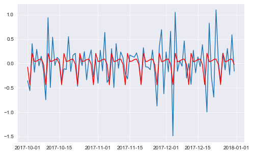

```python
from sklearn.metrics import mean_squared_error
from matplotlib import pyplot
error = mean_squared_error(test, predictions2)
print('Test MSE: %.3f' % error)
# plot results

pyplot.plot(test)
pyplot.plot(predictions2, color='red')
pyplot.show()
```

**Observation**

MSE is less than that obtained with AR model.

- Observing the plot of **__expected__** vs the **__predicted__** .

#### 8.3 ARIMA Model

```python
from statsmodels.tsa.arima_model import ARIMA
model = ARIMA(train, order = (7,0,7))
print('Lag: %s' % model_fit.k_ar)
print('Coefficients: %s' % model_fit.params)
print(model_fit.summary())

#ARIMA(7,0,7) = ARMA (7,7)
```

```
Lag: 7
Coefficients: const          0.000449
ar.L1.sales   -0.980352
ar.L2.sales   -0.979860
ar.L3.sales   -0.979721
ar.L4.sales   -0.979874
ar.L5.sales   -0.980331
ar.L6.sales   -0.979101
ar.L7.sales    0.020862
ma.L1.sales    0.107285
ma.L2.sales    0.080399
ma.L3.sales    0.099381
ma.L4.sales    0.104940
ma.L5.sales    0.088644
ma.L6.sales    0.102245
ma.L7.sales   -0.870005
dtype: float64
                              ARMA Model Results
==============================================================================
Dep. Variable:                  sales   No. Observations:                 1733
Model:                     ARMA(7, 7)   Log Likelihood               -1475.832
Method:                       css-mle   S.D. of innovations              0.256
Date:                Fri, 26 Jun 2020   AIC                           2983.663
Time:                        00:53:11   BIC                           3070.985
Sample:                    01-02-2013   HQIC                          3015.959
                         - 09-30-2017
===============================================================================
                  coef    std err          z      P>|z|      [0.025      0.975]
-------------------------------------------------------------------------------
const           0.0004      0.001      0.392      0.695      -0.002       0.003
ar.L1.sales    -0.9804        nan        nan        nan         nan         nan
ar.L2.sales    -0.9799        nan        nan        nan         nan         nan
ar.L3.sales    -0.9797        nan        nan        nan         nan         nan
ar.L4.sales    -0.9799        nan        nan        nan         nan         nan
ar.L5.sales    -0.9803        nan        nan        nan         nan         nan
ar.L6.sales    -0.9791        nan        nan        nan         nan         nan
ar.L7.sales     0.0209        nan        nan        nan         nan         nan
ma.L1.sales     0.1073      0.044      2.465      0.014       0.022       0.193
ma.L2.sales     0.0804      0.038      2.130      0.033       0.006       0.154
ma.L3.sales     0.0994      0.048      2.071      0.039       0.005       0.193
```

[output cut: 8 more lines]

```
AR.1            0.6234           -0.7819j            1.0000           -0.1429
AR.2            0.6234           +0.7819j            1.0000            0.1429
AR.3           -0.9011           -0.4337j            1.0000           -0.4286
AR.4           -0.9011           +0.4337j            1.0000            0.4286
AR.5           -0.2229           -0.9748j            1.0000           -0.2858
AR.6           -0.2229           +0.9748j            1.0000            0.2858
AR.7           47.9324           -0.0000j           47.9324           -0.0000
MA.1           -0.9013           -0.4335j            1.0002           -0.4286
MA.2           -0.9013           +0.4335j            1.0002            0.4286
MA.3           -0.2260           -0.9834j            1.0090           -0.2860
MA.4           -0.2260           +0.9834j            1.0090            0.2860
MA.5            0.6284           -0.7853j            1.0058           -0.1426
MA.6            0.6284           +0.7853j            1.0058            0.1426
MA.7            1.1155           -0.0000j            1.1155           -0.0000
-----------------------------------------------------------------------------
```

```python
results_ARIMA= model.fit()
```

```python
results_ARIMA.fittedvalues.head()
```

```
date
2013-01-02    0.000449
2013-01-03    0.003598
2013-01-04    0.111959
2013-01-05   -0.252501
2013-01-06    0.216615
dtype: float64
```

```python
# make predictions
predictions3 = results_ARIMA.predict(start=len(train), end=len(train)+len(test)-1)
predictions3.head()

for i in range(len(predictions2)):
    print('predicted=%f, expected=%f' % (predictions3[i], test.iloc[i]))
```

```
predicted=-0.077149, expected=-0.356675
predicted=-0.440768, expected=-0.559616
predicted=0.202448, expected=0.405465
predicted=0.039366, expected=-0.182322
predicted=0.047784, expected=0.287682
predicted=0.078547, expected=-0.051293
predicted=0.088151, expected=0.146603
predicted=-0.014212, expected=-0.146603
predicted=-0.439143, expected=-0.747214
predicted=0.203027, expected=0.938270
predicted=0.038922, expected=-0.496437
predicted=0.047822, expected=0.538997
predicted=0.078717, expected=-0.042560
predicted=0.088237, expected=0.122602
predicted=-0.014911, expected=0.074108
predicted=-0.438844, expected=-0.387766
predicted=0.203578, expected=-0.111226
predicted=0.038476, expected=-0.125163
predicted=0.047862, expected=0.550046
predicted=0.078887, expected=-0.167054
predicted=0.088321, expected=0.167054
predicted=-0.015609, expected=0.207639
predicted=-0.438544, expected=-0.470004
predicted=0.204128, expected=0.139762
predicted=0.038029, expected=-0.044452
predicted=0.047903, expected=0.241162
predicted=0.079057, expected=-0.336472
predicted=0.088404, expected=0.095310
predicted=-0.016308, expected=0.276253
predicted=-0.438242, expected=-0.276253
predicted=0.204676, expected=0.087011
predicted=0.037582, expected=-0.405465
predicted=0.047945, expected=0.271934
predicted=0.079227, expected=-0.154151
predicted=0.088485, expected=0.635989
predicted=-0.017006, expected=-0.390866
predicted=-0.437938, expected=-0.302281
predicted=0.205223, expected=0.302281
predicted=0.037135, expected=-0.496437
predicted=0.047988, expected=0.405465
```

[output cut: 37 more lines]

```
predicted=-0.021190, expected=0.382992
predicted=-0.436076, expected=-0.146603
predicted=0.208477, expected=-0.998529
predicted=0.034435, expected=0.826679
predicted=0.048271, expected=-0.287682
predicted=0.080425, expected=-0.693147
predicted=0.089020, expected=1.098612
predicted=-0.021886, expected=0.054067
predicted=-0.435760, expected=-0.379490
predicted=0.209015, expected=0.207639
predicted=0.033983, expected=-0.133531
predicted=0.048322, expected=0.305382
predicted=0.080597, expected=-0.236389
predicted=0.089091, expected=0.587787
predicted=-0.022583, expected=-0.160343
```

```
Test MSE: 0.142
```

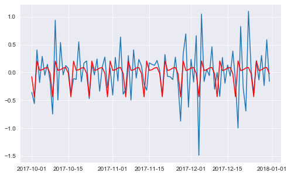

```python
from sklearn.metrics import mean_squared_error
from matplotlib import pyplot
error = mean_squared_error(test, predictions3)
print('Test MSE: %.3f' % error)
# plot results

pyplot.plot(test)
pyplot.plot(predictions3, color='red')
pyplot.show()
```

**Observation**

MSE is less than that obtained with AR model but same as ARMA model.

- Observing the plot of **__expected__** vs the **__predicted__** .

### Prediction & Reverse transformations of fittedvalues

```python
predictions_ARIMA_diff = pd.Series(results_ARIMA.fittedvalues, copy=True)
predictions_ARIMA_diff.head()
```

```
date
2013-01-02    0.000449
2013-01-03    0.003598
2013-01-04    0.111959
2013-01-05   -0.252501
2013-01-06    0.216615
dtype: float64
```

```python
predictions_ARIMA_diff_cumsum = predictions_ARIMA_diff.cumsum()
predictions_ARIMA_diff_cumsum.head()
```

```
date
2013-01-02    0.000449
2013-01-03    0.004047
2013-01-04    0.116006
2013-01-05   -0.136495
2013-01-06    0.080120
dtype: float64
```

```python
predictions_ARIMA_log = pd.Series(indexedDataset_logScale['sales'].iloc[0], index=datasetLogDiffShifting.index)
predictions_ARIMA_log = predictions_ARIMA_log.add(predictions_ARIMA_diff_cumsum,fill_value=0)
predictions_ARIMA_log.head()
```

```
date
2013-01-02    2.565398
2013-01-03    2.568996
2013-01-04    2.680956
2013-01-05    2.428454
2013-01-06    2.645069
dtype: float64
```

```python
reverted_back_prediction = pd.DataFrame(np.exp(predictions_ARIMA_log))
reverted_back_prediction.head()

# all transforormation in reverse order.
```

| date | 0 |
| --- | --- |
| 2013-01-02 | 13.005839 |
| 2013-01-03 | 13.052718 |
| 2013-01-04 | 14.599036 |
| 2013-01-05 | 11.341335 |
| 2013-01-06 | 14.084415 |

[figure not shown]

```python
from matplotlib import pyplot

pyplot.plot(reverted_back_prediction, color='red')
pyplot.plot(indexedDataset.tail(180))
pyplot.show()
```

```python
indexedDataset_logScale.columns = ['sales in logscale']
reverted_back_prediction.columns = ['ARIMA Predicted sales']
datasetLogDiffShifting.columns = ['sales after log diff shifting']
```

```python
df = pd.concat([indexedDataset,indexedDataset_logScale, datasetLogDiffShifting,reverted_back_prediction], axis=1, sort=False)
df.tail(10)
```

| date | sales | sales in logscale | sales after log diff shifting | ARIMA Predicted sales |
| --- | --- | --- | --- | --- |
| 2017-12-22 | 6.0 | 1.791759 | -0.693147 | 13.0 |
| 2017-12-23 | 18.0 | 2.890372 | 1.098612 | 13.0 |
| 2017-12-24 | 19.0 | 2.944439 | 0.054067 | 13.0 |
| 2017-12-25 | 13.0 | 2.564949 | -0.379490 | 13.0 |
| 2017-12-26 | 16.0 | 2.772589 | 0.207639 | 13.0 |
| 2017-12-27 | 14.0 | 2.639057 | -0.133531 | 13.0 |
| 2017-12-28 | 19.0 | 2.944439 | 0.305382 | 13.0 |
| 2017-12-29 | 15.0 | 2.708050 | -0.236389 | 13.0 |
| 2017-12-30 | 27.0 | 3.295837 | 0.587787 | 13.0 |
| 2017-12-31 | 23.0 | 3.135494 | -0.160343 | 13.0 |

### Forecasting the sales for the next 3 months

- We have 1826(existing data of 5 yrs in days) data points of item 1 in store 1.  
  To forecast additional 90 data points or **3 months**.
- Using plot_predict method

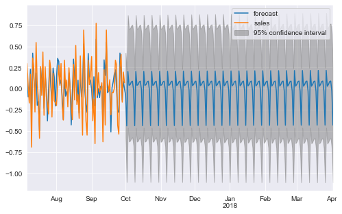

[figure not shown]

```python
results_ARIMA.plot_predict(1646,1916)
```

```python
three_months_forecast = results_ARIMA.predict(start=len(train), end=len(train)+len(test)-1+90 )
```

### Prediction & Reverse transformations of 3 months forecast

```python
predictions_ARIMA_diff = pd.Series(three_months_forecast, copy=True)
predictions_ARIMA_diff.head()
```

```
2017-10-01   -0.077149
2017-10-02   -0.440768
2017-10-03    0.202448
2017-10-04    0.039366
2017-10-05    0.047784
Freq: D, dtype: float64
```

```python
predictions_ARIMA_diff_cumsum = predictions_ARIMA_diff.cumsum()
predictions_ARIMA_diff_cumsum.head()
```

```
2017-10-01   -0.077149
2017-10-02   -0.517917
2017-10-03   -0.315469
2017-10-04   -0.276103
2017-10-05   -0.228320
Freq: D, dtype: float64
```

```python
predictions_ARIMA_log = pd.Series(indexedDataset_logScale['sales in logscale'].iloc[-1], index=predictions_ARIMA_diff.index)
predictions_ARIMA_log = predictions_ARIMA_log.add(predictions_ARIMA_diff_cumsum,fill_value=0)
predictions_ARIMA_log.tail()
```

```
2018-03-27    2.908002
2018-03-28    2.936049
2018-03-29    2.985138
2018-03-30    3.067982
2018-03-31    3.157875
Freq: D, dtype: float64
```

```python
reverted_back_prediction = pd.DataFrame(np.exp(predictions_ARIMA_log))
reverted_back_prediction.head()
```

|  | 0 |
| --- | --- |
| 2017-10-01 | 21.292284 |
| 2017-10-02 | 13.702484 |
| 2017-10-03 | 16.777266 |
| 2017-10-04 | 17.450892 |
| 2017-10-05 | 18.305003 |

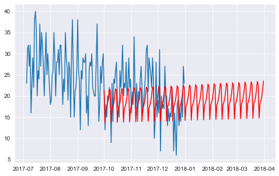

```python
from matplotlib import pyplot
pyplot.plot(indexedDataset.tail(180))
pyplot.plot(reverted_back_prediction, color='red')
pyplot.show()
```